# Part_II_slide_deck_template-checkpoint slides

## Effect of borrower interest rate from Prosper Loan Data

## Investigation Overview

Prosper is loan company, The purpose of this project is to look at the primary factors of loans and borrowers interest rate that might be used to predict their progression.

## Dataset Overview

> The Prosper loan dataset comprises of 113937 loan entries with 81 attributes on each loan which include so many attribute of borrowers eg employement status , occupation, creditgrade etc

## Loan Status

> Over 80% of all loans on Prosper are either current or paid completed. 10.5% of Prosper's loans were charged off and 4.4% all went into default. Additionally, 1.8% of debts were lumped under the classification of Past Due and 0,2% went into finalpaymentprogress

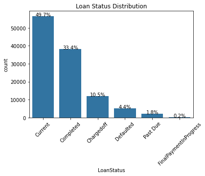

## Loan Original Amount Distribution

> There are three peaks at 4K, 10K, and 15K, as can be seen. These three loan sizes appear to be the most popular ones that people have taken out.

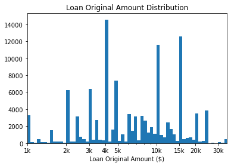

## Relation between Borrower Rate and Prosper Score, Prosper Rating

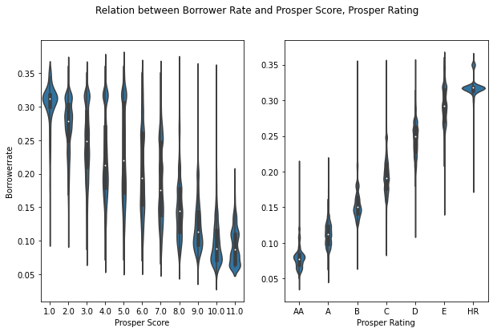

## Borrower Rate by Prosper Rating and Loan terms

We note that the rates applied on 5-year loans are generally higher than the rates applied on other maturities, regardless of the prosper rating (with the exception of the E rating (same rates for 3 and 5 years loans ) and the HR rating)

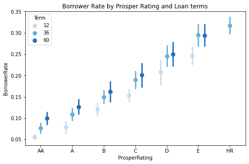